# Comparing GCAM soil organic carbon predictions to empirical land use results

01 September 2024

# 1 Methods

To begin the analysis, SOC data was taken from a basic run of GCAM, called a reference scenario. This models “business as usual” for the world, without any extra climate policies and assuming a certain level of overall warming. This GitHub repository contains all relevant data from this reference scenario used in our analysis, which was performed using R. Note that the SOC data, GCAM’s soil timescale list, as well as both the geopolitical regions list and the land use regions list are separate files, and must be merged before any additional steps can be performed. Below is the code used to load the data and libraries, as well as to merge the four files listed above. The final product is a data set where each SOC data point has an associated timescale value, land use region, and geopolitical region.

```r
library(dplyr)
library(ggplot2)
library(metafor)
library(tidyr)


#GCAM's SOC data
soilC <- read.csv(file = 'Data/GCAM_soilC.csv')

#GCAM's soil timescale list
read.csv(file = 'Data/soil_timescales.csv') %>%
  mutate(GCAM_region_ID = seq(1,32,by=1))-> timescales

#GCAM's land use region list
glus <- read.csv(file = 'Data/GLU_codes.csv')

#GCAM's geopolitical region list
regions <- read.csv('Data/GCAM_regions.csv')

#Merging the four above data sets
soilC %>%
  mutate(GLU_code = GLU) %>%
  right_join(glus, by='GLU_code') %>%
  right_join(regions, by='GCAM_region_ID') %>%
  right_join(timescales, by='GCAM_region_ID')-> soilC_regions
```

Much of the data contained within the SOC data set is irrelevant to this analysis, so it was removed.

```r
soilC_regions %>%
  select(Land_Type, soil_c, GLU_code, soilTimeScale, GCAM_region_ID, Basin_long_name) -> simple_soilC_regions
```

The experimental data compared to GCAM’s outputs was taken from Post & Kwon (2000) and Wei et al. (2014), both reviews of SOC measurements from the past 70 years. This data was manually digitized into a CSV file for analysis. This data did not explicitly list site locations for each measurement, so this information was determined from the paper referenced by the two studies. Once the location was determined, it was compared to GCAM’s 384 land use regions using the rmap tool and GCAM’s basin code mapping file. Then, the GLU code was manually added to the digitized data from Post & Kwon.

Once fully digitized, the experimental data was loaded into R as well. Note that there were several entries with missing timeframes or where the location of the sample could not be determined. These were assigned a value of ‘NA’.

```r
PostKwon <- read.csv(file= 'Data/Experimental Data.csv', na.strings = c("", "NA"))
Wei <- read.csv(file= 'Data/Wei et al Data.csv', na.strings = c("", "NA"))
```

Once the experimental data was loaded in, each observation was mapped to is corresponding GCAM data point. This was done by simply adding the previously created GCAM data set to the experimental one by land use region, geopolitical region, and land use. This process was done twice–once for the initial land use and once for the final land use. This meant that, ultimately, each experimental data point had two associated GCAM SOC values–one for the initial land use, and one for the final land use.

$$\begin{equation}
\tag{2}
k = -\frac{ln (Rate \times t + 1)}{t}
\end{equation}$$

Experimental data from Wei et al. did not contain any raw rate information. Instead, the study only reported percent decrease in SOC concentration. This means we were only able to compare k values between the Wei et. al. data and GCAM. Additionally, k had to be computed with a modified equation, 3, below.

$$\begin{equation}
\tag{3}
k = -\frac{ln \left(\frac{1}{\frac{|OC Decrease|}{100} + 1}\right)}{t}
\end{equation}$$

The code for merging the GCAM and experimental, as well as for computing the rate and k value is below. The process was the same for the Wei et al. data.

```r
PostKwon %>%
  select(Initial_Land_Use, Final_Land_Use, GLU_code, GCAM_region_ID, Time, Exp_Rate) %>%
  na.omit() %>%
  mutate(Land_Type = Initial_Land_Use) %>%
  right_join(simple_soilC_regions, by = c('GLU_code', 'Land_Type', 'GCAM_region_ID')) %>%
  rename(initial_soil_c = soil_c) %>%
  select(-Land_Type) %>%
  mutate(Land_Type = Final_Land_Use) %>%
  right_join(simple_soilC_regions, by = c('GLU_code', 'Land_Type', 'GCAM_region_ID')) %>%
  rename(final_soil_c = soil_c) %>%
  select(-Land_Type, -soilTimeScale.x, -Basin_long_name.x) %>%
  rename(soilTimeScale = soilTimeScale.y, Basin_long_name = Basin_long_name.y) %>%
  na.omit() %>%
  mutate(GCAM_Rate = (final_soil_c - initial_soil_c)/soilTimeScale, Rate_Difference = Exp_Rate - GCAM_Rate,
         Exp_k = -log(abs(Exp_Rate)*Time +1)/Time,
         GCAM_k = -log(final_soil_c/initial_soil_c)/soilTimeScale,
         source = 'Post & Kwon'
  ) %>%
  #This next line corrects the sign of Exp_k--we had to take the absolute value to avoid NaNs, so this accounts for that
  #This did not have to be done for the GCAM_k because the argument inside the natural log will always be positive--it is a positive value divided by another positive value--so sign correction was not necesary.
  mutate(Exp_k = ifelse(sign(Exp_k) == sign(Exp_Rate), Exp_k*(-1), Exp_k)) -> PostKwon_Comparison
```

Note that, because of how the k value is computed for the experimental data, the sign was often mismatched. The sign of k corresponds to the opposite of the sign of the rate, which had to be corrected manually.

Once the experimental data was matched to its corresponding GCAM outputs, the two data sets (Post& Kwon and Wei et al.) were merged. Importantly, because the rate data does not exist for Wei et al., the rate data was not included in the aggregated data set.

```r
Full_Comparison <- bind_rows(
  select(PostKwon_Comparison, -Exp_Rate, -Rate_Difference),
  select(Wei_Comparison, -OC_decrease)
  )
```

Once the k values were calculated, t-tests and ANOVAs were performed on the data to determine if there was a significant difference of the means of the empirical and GCAM k values. Before the t-tests were performed, the data had to be put in long form and a transition type column was added:

```r
Full_Comparison %>%
  pivot_longer(cols = Exp_k:GCAM_k,
               names_to = "Type",
               values_to = "k") -> full_long_data

full_long_data %>%
  mutate(change = paste(Initial_Land_Use, Final_Land_Use, sep = '')) -> change_long_data
```

Then, the ANOVAs could be performed. The Akaike information criterion was used to assess which ANOVA best captured the data.

```r
#Type + Basin (no average)
aov_Full <- aov(k ~ Type + Basin_long_name ,
                      data = full_long_data)
summary(aov_Full)
TukeyHSD(aov_Full)
AIC(aov_Full)


#Type + Change (no average)
aov_Full_change <- aov(k ~ Type + change,
                      data = change_long_data)
summary(aov_Full_change)
TukeyHSD(aov_Full_change)
AIC(aov_Full_change)

#Type * Change (no average)
aov_Full_change_times <- aov(k ~ Type * change,
                       data = change_long_data)
summary(aov_Full_change_times)
TukeyHSD(aov_Full_change_times)
AIC(aov_Full_change_times)

#Type + Basin + change
aov_big <- aov(k ~ Type + Basin_long_name + change,
               data = change_long_data)
summary(aov_big)
TukeyHSD(aov_big)
AIC(aov_big)



#Now, we'll do some averages
#Type + change (averaged by change)
change_long_data %>%
  group_by(Type, change) %>%
  summarize(mean_k = mean(k), std_dev_k = sd(k)) -> change_grouped_long
aov_change <- aov(mean_k ~ Type + change,
               data = change_grouped_long)
summary(aov_change)
TukeyHSD(aov_change)
AIC(aov_change)


#Type + Basin (averaged by basin)
#Average by region
change_long_data %>%
  group_by(Type, Basin_long_name) %>%
  summarize(mean_k = mean(k), std_dev_k = sd(k)) -> basin_grouped_long
aov_basin <- aov(mean_k ~ Type + Basin_long_name,
                  data = basin_grouped_long)
summary(aov_basin)
AIC(aov_basin)
```

# 2 Results

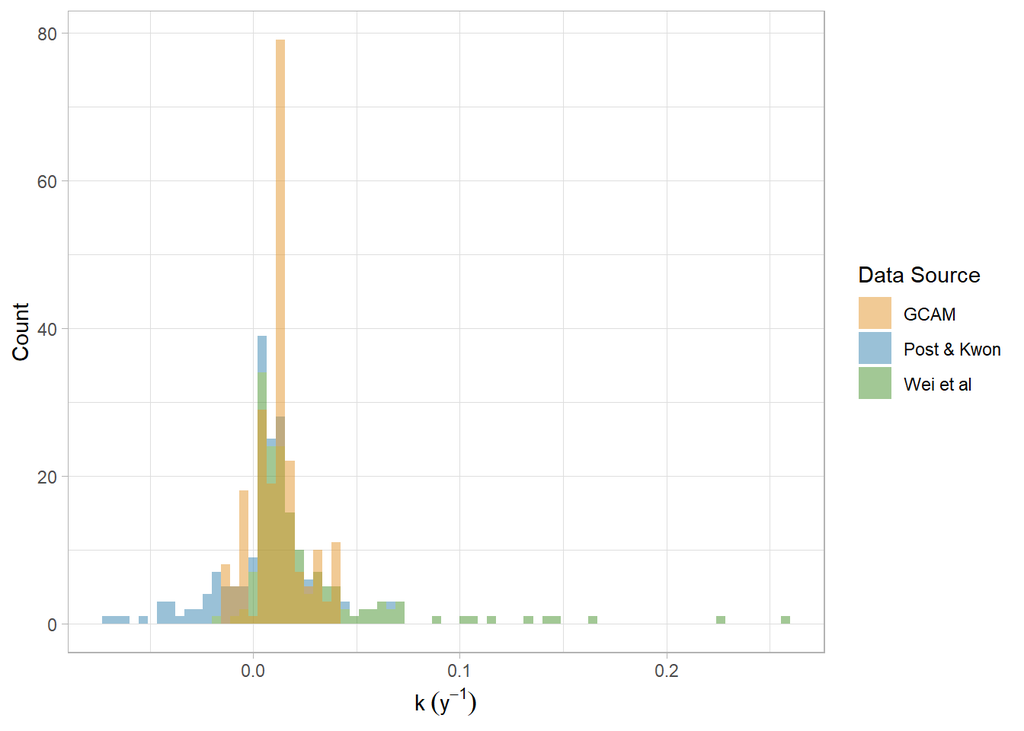

Figure 2.1: Histograms showing overlapping GCAM and experimental data for computed k values during land use change. Here, the experimental data is taken from both Post & Kwon and Wei et al.

```r
t.test(PostKwon_Comparison$Exp_k, PostKwon_Comparison$GCAM_k, alternative = 'two.sided')
```

```
##
##  Welch Two Sample t-test
##
## data:  PostKwon_Comparison$Exp_k and PostKwon_Comparison$GCAM_k
## t = -3.2188, df = 62.238, p-value = 0.002046
## alternative hypothesis: true difference in means is not equal to 0
## 95 percent confidence interval:
##  -0.019747792 -0.004617514
## sample estimates:
##    mean of x    mean of y
## -0.013394274 -0.001211622
```

```r
t.test(Wei_Comparison$Exp_k, Wei_Comparison$GCAM_k, alternative = 'two.sided')
```

```
##
##  Welch Two Sample t-test
##
## data:  Wei_Comparison$Exp_k and Wei_Comparison$GCAM_k
## t = 2.9157, df = 181.19, p-value = 0.003997
## alternative hypothesis: true difference in means is not equal to 0
## 95 percent confidence interval:
##  0.002867409 0.014872597
## sample estimates:
##  mean of x  mean of y
## 0.02555813 0.01668813
```

```r
t.test(Full_Comparison$Exp_k, Full_Comparison$GCAM_k, alternative = 'two.sided')
```

```
##
##  Welch Two Sample t-test
##
## data:  Full_Comparison$Exp_k and Full_Comparison$GCAM_k
## t = 1.3443, df = 254.22, p-value = 0.18
## alternative hypothesis: true difference in means is not equal to 0
## 95 percent confidence interval:
##  -0.001733325  0.009189545
## sample estimates:
##  mean of x  mean of y
## 0.01604441 0.01231630
```

Based on the AIC for each ANOVA, the tests accounting for data source + transition type and data soruce + basin + transition type were used. These tests whoed no significant difference in means based on data source.

```r
summary(aov_Full_change)
```

```
##              Df  Sum Sq  Mean Sq F value Pr(>F)
## Type          1 0.00151 0.001508   2.199  0.139
## change        7 0.06897 0.009852  14.363 <2e-16 ***
## Residuals   425 0.29152 0.000686
## ---
## Signif. codes:  0 '***' 0.001 '**' 0.01 '*' 0.05 '.' 0.1 ' ' 1
```

```r
summary(aov_big)
```

```
##                  Df  Sum Sq  Mean Sq F value   Pr(>F)
## Type              1 0.00151 0.001508   2.323    0.128
## Basin_long_name  48 0.08615 0.001795   2.765 3.73e-08 ***
## change            5 0.02827 0.005654   8.709 7.85e-08 ***
## Residuals       379 0.24606 0.000649
## ---
## Signif. codes:  0 '***' 0.001 '**' 0.01 '*' 0.05 '.' 0.1 ' ' 1
```

The average of the difference in means between k values was also plotted, grouped by transition type:

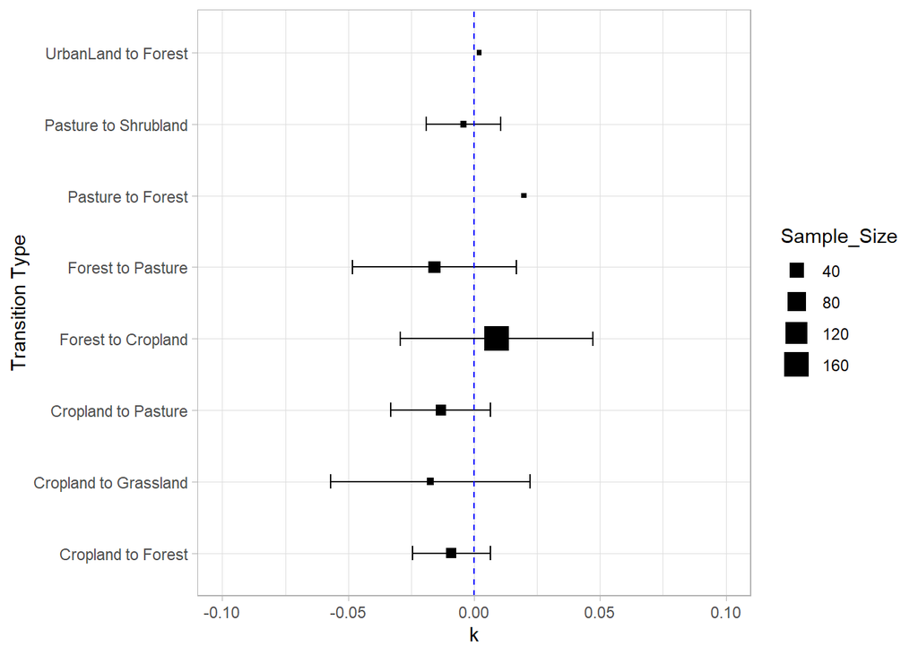

```r
#Make the mean graph
Full_Comparison %>%
  mutate(change = paste(Initial_Land_Use, Final_Land_Use, sep = ' to ')) %>%
  mutate(difference = Exp_k - GCAM_k) %>%
  group_by(change) %>%
  summarise(Mean_k = mean(difference), std_dev = sd(difference), Sample_Size = n()) -> mean_difference

ggplot(mean_difference, aes(x = Mean_k, y = change)) +
  geom_point(aes(size = Sample_Size), shape = 15) +
  labs(x = 'k', y = 'Transition Type') +
  geom_errorbar(aes(xmin=Mean_k - std_dev, xmax=Mean_k + std_dev), width=.2,
                position=position_dodge(0.05)) +
  xlim(-0.1, 0.1) +
  geom_vline(xintercept = 0, linetype = 'dashed', color = 'blue') +
  theme_light()
```